# RAISING implementation

RAISING is a neural network(NN) framework implemented in a two stage approach, first performing hyperparameter tuning to devise the best NN architecture then training on the data to estimate the feature importance. Here we describe the implementation of RAISING on a simulated data.

## Package installation

Assuming package folder has been downloaded, package folder contains RAISING, README_RAISING.html, simulated data(sim1.csv), and this document explaining the implementation of RAISING.To install the RAISING package, open your terminal, navigate to the package directory, and run the following command:

```python
#pip install -e RAISING
```

## Import required libraries

```python
import pandas as pd
from RAISING.hp_tune_select import *
```

## Load simulated data

We will use the simulated data from capblancq et. al.(2018) stored in sim1.csv. There are 64 population and authors have sampled 10 individuals from each of the the population at the end of simulations. Simulated data has 640 individuals and 1000 Loci which is input data and output data has 640 individuals and 10 environmental factors.

```python
df = pd.read_csv("sim1.csv")
```

We will store the input genotype matrix into X_data variable and environmental matrix in y_data

```python
X_data = df.iloc[:,14:]
X_data.columns = ["X" + str(i) for i in range(1, X_data.shape[1]+1)]

y_data = df.iloc[:,1:11]
print(X_data.head())
print(y_data.head())
```

```
   X1  X2  X3  X4  X5  X6  X7  X8  X9  X10  ...  X991  X992  X993  X994  X995  \
0   2   1   1   2   1   1   1   2   2    2  ...     0     0     2     2     1
1   2   0   1   0   0   2   1   0   1    1  ...     0     2     2     0     0
2   1   1   0   1   2   2   1   1   1    2  ...     1     1     2     0     2
3   0   0   1   0   1   0   1   2   1    0  ...     2     1     1     1     1
4   1   0   0   1   2   1   1   1   1    1  ...     2     1     2     0     1

   X996  X997  X998  X999  X1000
0     2     1     0     1      2
1     0     0     0     2      2
2     2     1     2     1      0
3     2     0     0     2      1
4     1     1     1     0      0

[5 rows x 1000 columns]
     envir1    envir2    envir3    envir4    envir5    envir6    envir7  \
0  2.617145  3.409281  1.824793  2.086641  2.653106  1.922795  2.750581
1  2.617145  3.409281  1.824793  2.086641  2.653106  1.922795  2.750581
2  2.617145  3.409281  1.824793  2.086641  2.653106  1.922795  2.750581
3  2.617145  3.409281  1.824793  2.086641  2.653106  1.922795  2.750581
4  2.617145  3.409281  1.824793  2.086641  2.653106  1.922795  2.750581

    envir8    envir9   envir10
0 -0.52858  3.559023  8.363484
1 -0.52858  3.559023  8.363484
2 -0.52858  3.559023  8.363484
3 -0.52858  3.559023  8.363484
4 -0.52858  3.559023  8.363484
```

## Stage 1 : Hyperparameter tuning

We will use hp_optimization() function defined in RAISING for hyperparameter tuning.The description of the function can be found in README file **README_RAISING.html**

```python
model = hp_optimization(input_data=X_data, output_data=y_data, objective_fun="val_loss", output_class="continuous", max_trials=10)
```

```python
print(model.summary())
```

```
Model: "sequential_1"
_________________________________________________________________
 Layer (type)                Output Shape              Param #
=================================================================
 dense_3 (Dense)             (None, 37)                37037

 dropout_2 (Dropout)         (None, 37)                0

 dense_4 (Dense)             (None, 10)                380

=================================================================
Total params: 37,417
Trainable params: 37,417
Non-trainable params: 0
_________________________________________________________________
None
```

## Stage 2 : Feature Selection

We will use feature_importance() function defined in RAISING for feature selection.The description of the function can be found in README file **README_RAISING.html**

```python
GenFeat_df = feature_importance(input_data=X_data, output_data=y_data, feature_set=X_data.columns.to_list(), iteration=10, feature_method="DeepFeatImp")
```

We will scale the feature importance f genetic loci between [0,1] corresponding to linear environment gradient(envir2). We will generate a plot where we will have on the x-axis (genetic loci position) and on the y-axis (feature importance corresponding to linear environment)

```python
def minmaxscale(vec):
        return((vec - min(vec))/(max(vec) - min(vec)))

GenFeat_df["scaled_feat"] = minmaxscale(vec = GenFeat_df["envir2"])
GenFeat_df["loci_index"] = GenFeat_df.index+1
```

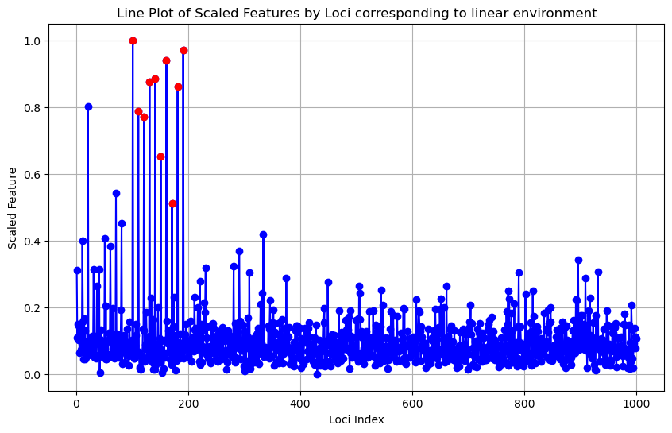

```python
import matplotlib.pyplot as plt

actual_pos = [101,111,121,131,141,151,161,171,181,191]

plt.figure(figsize=(10, 6))
plt.plot(GenFeat_df['loci_index'], GenFeat_df['scaled_feat'], marker='o', linestyle='-', color='b')

highlight_df = GenFeat_df[GenFeat_df['loci_index'].isin(actual_pos)]
plt.scatter(highlight_df['loci_index'], highlight_df['scaled_feat'], color='red', zorder=5)

plt.title('Line Plot of Scaled Features by Loci corresponding to linear environment')
plt.xlabel('Loci Index')
plt.ylabel('Scaled Feature')
plt.grid(True)
plt.show()
```